# Tidy Tuesday 5-17-2022: Eurovision

2022-05-17

## The Data

This week’s data comes from [Eurovision](https://eurovision.tv/) which is a song contest for European countries. The data describes the event location, year, section etc. as well as the competitors’ ranks, points, and associated country.

```r
library(tidyverse)
library(skimr)
library(dplyr)
```

```r
eurovision <- readr::read_csv('https://raw.githubusercontent.com/rfordatascience/tidytuesday/master/data/2022/2022-05-17/eurovision.csv')

eurovision_votes <- readr::read_csv('https://raw.githubusercontent.com/rfordatascience/tidytuesday/master/data/2022/2022-05-17/eurovision-votes.csv')
```

## Data Exploration

To start off, I tend to use glimpse and skim to better understand the structure of the data as well as the structure of each variable in the data frame.

```r
glimpse(eurovision)
skim(eurovision)
```

## Plotting the Number of Self-Votes

For this Tidy Tuesday, I wanted to see the number of self-votes (i.e. when a country votes for itself) in Eurovision.

```r
eurovision_votes <- eurovision_votes %>%
  mutate(self.voting = if_else(from_country == to_country, 1, 0))
```

```r
votes_country <- eurovision_votes %>%
  group_by(from_country) %>%
  summarise(Total.self.votes = sum(self.voting))
```

Finally, I plotted it! I wanted to include all countries so apologies for small y-axis font. I do think it is interesting to see which countries voted for themselves the most versus those that did the least. A potential cool follow-up would be to facet by something like year or decade. Potentially, self-votes are associated with historical events in the country. For example, maybe Russia voted for itself the most during the Cold War. Maybe if I have time in the future, I will play around with this.

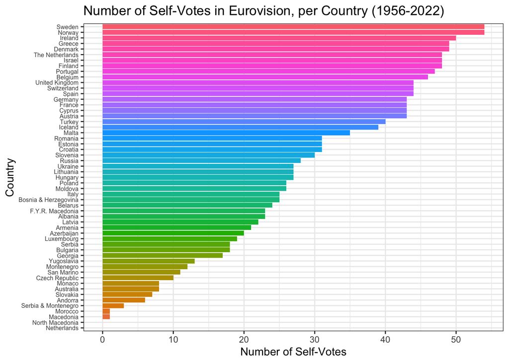

```r
votes_country %>%
  ggplot(aes(x = reorder(from_country, Total.self.votes), y = Total.self.votes, fill = reorder(from_country, Total.self.votes)))+
  geom_bar(stat = "identity", show.legend = FALSE)+
  theme_bw()+
  theme(axis.text.y=element_text(size=6))+
  scale_y_continuous(breaks=seq(0,60,by=10))+
  coord_flip()+
  xlab("Country")+
  ylab("Number of Self-Votes")+
  ggtitle("Number of Self-Votes in Eurovision, per Country (1956-2022)")
```